# BimboInventoryDemand

Juliana Yamauti

14/10/2020

# Grupo Bimbo Inventory Demand

Dataset: https://www.kaggle.com/c/grupo-bimbo-inventory-demand

### The goal in this project is to create a develop a model to accurately forecast inventory demand based on historical sales data

Loading necessary packages:

```r
library(data.table)
library(dplyr)
library(caret)
library(ggplot2)
library(reshape2)
library(MLmetrics)
```

Loading aditional datasets:

```r
df_cliente <- fread("cliente_tabla.csv", header = TRUE, sep = ",", encoding = "UTF-8")
head(df_cliente)
```

```
##    Cliente_ID                           NombreCliente
## 1:          0                              SIN NOMBRE
## 2:          1                        OXXO XINANTECATL
## 3:          2                              SIN NOMBRE
## 4:          3                               EL MORENO
## 5:          4 SDN SER  DE ALIM  CUERPO SA CIA  DE INT
## 6:          4    SDN SER DE ALIM CUERPO SA CIA DE INT
```

```r
dim(df_cliente)
```

```
## [1] 935362      2
```

```r
df_produto <- fread("producto_tabla.csv", header = TRUE, sep = ",", encoding = "UTF-8")
head(df_produto)
```

```
##    Producto_ID                         NombreProducto
## 1:           0                      NO IDENTIFICADO 0
## 2:           9              Capuccino Moka 750g NES 9
## 3:          41 Bimbollos Ext sAjonjoli 6p 480g BIM 41
## 4:          53         Burritos Sincro 170g CU LON 53
## 5:          72    Div Tira Mini Doradita 4p 45g TR 72
## 6:          73      Pan Multigrano Linaza 540g BIM 73
```

```r
dim(df_produto)
```

```
## [1] 2592    2
```

```r
df_town <- fread("town_state.csv", header = TRUE, sep = ",", encoding = "UTF-8")
head(df_town)
```

```
##    Agencia_ID                  Town            State
## 1:       1110    2008 AG. LAGO FILT     MÉXICO, D.F.
## 2:       1111 2002 AG. AZCAPOTZALCO     MÉXICO, D.F.
## 3:       1112   2004 AG. CUAUTITLAN ESTADO DE MÉXICO
## 4:       1113    2008 AG. LAGO FILT     MÉXICO, D.F.
## 5:       1114  2029 AG.IZTAPALAPA 2     MÉXICO, D.F.
## 6:       1116  2011 AG. SAN ANTONIO     MÉXICO, D.F.
```

```r
dim(df_town)
```

```
## [1] 790   3
```

Loading train dataset:

```r
df_train <- fread("train.csv", header = TRUE, sep = ",", encoding = "UTF-8")
head(df_train)
```

```
##    Semana Agencia_ID Canal_ID Ruta_SAK Cliente_ID Producto_ID Venta_uni_hoy
## 1:      3       1110        7     3301      15766        1212             3
## 2:      3       1110        7     3301      15766        1216             4
## 3:      3       1110        7     3301      15766        1238             4
## 4:      3       1110        7     3301      15766        1240             4
## 5:      3       1110        7     3301      15766        1242             3
## 6:      3       1110        7     3301      15766        1250             5
##    Venta_hoy Dev_uni_proxima Dev_proxima Demanda_uni_equil
## 1:     25.14               0           0                 3
## 2:     33.52               0           0                 4
## 3:     39.32               0           0                 4
## 4:     33.52               0           0                 4
## 5:     22.92               0           0                 3
## 6:     38.20               0           0                 5
```

```r
dim(df_train)
```

```
## [1] 74180464       11
```

df_train dataset has 74.180.464 observations and 11 variables. Since the dataset is too big, we’re going to get a 100.000 rows’ sample

```r
df_sample <- sample_n(df_train, size = 100000)
dim(df_sample)
```

```
## [1] 100000     11
```

```r
# Removing df_train object
rm(df_train)

# Saving the sample into "AmostraBimbo.csv" so we don't have to load train dataset again
write.csv(df_sample, "AmostraBimbo.csv")

# Reading the sample file
df_sample <- fread("AmostraBimbo.csv", header = TRUE, sep = ",", encoding = "UTF-8")
head(df_sample)
```

```
##    V1 Semana Agencia_ID Canal_ID Ruta_SAK Cliente_ID Producto_ID Venta_uni_hoy
## 1:  1      4       1629        1     2870    4428423       43033             4
## 2:  2      7       1914        1     1231    1873324        1125             5
## 3:  3      6       1120        1     1080    2443869        2233             3
## 4:  4      4       1342        1     2004    1109880       37058             6
## 5:  5      3       1350        1     2824     379652       43069             3
## 6:  6      4       2017        1     1075     126285        1125            18
##    Venta_hoy Dev_uni_proxima Dev_proxima Demanda_uni_equil
## 1:     24.60               0         0.0                 4
## 2:     48.00               0         0.0                 5
## 3:     59.82               0         0.0                 3
## 4:     45.00               0         0.0                 6
## 5:     22.23               0         0.0                 3
## 6:    172.80               8        76.8                10
```

```r
# Removing column #1 with row number
df_sample$V1 <- NULL

# Convert df_sample to dataframe
class(df_sample)
```

```
## [1] "data.table" "data.frame"
```

```r
df_sample <- as.data.frame(df_sample)
```

## EDA - Exploratory Data Analysis

```r
# Checking dataset statistics
summary(df_sample)
```

```
##      Semana        Agencia_ID       Canal_ID         Ruta_SAK
##  Min.   :3.000   Min.   : 1110   Min.   : 1.000   Min.   :   1
##  1st Qu.:4.000   1st Qu.: 1311   1st Qu.: 1.000   1st Qu.:1160
##  Median :6.000   Median : 1613   Median : 1.000   Median :1283
##  Mean   :5.951   Mean   : 2545   Mean   : 1.386   Mean   :2111
##  3rd Qu.:8.000   3rd Qu.: 2036   3rd Qu.: 1.000   3rd Qu.:2802
##  Max.   :9.000   Max.   :25759   Max.   :11.000   Max.   :9826
##    Cliente_ID        Producto_ID    Venta_uni_hoy        Venta_hoy
##  Min.   :     105   Min.   :   72   Min.   :   0.000   Min.   :    0.00
##  1st Qu.:  356288   1st Qu.: 1242   1st Qu.:   2.000   1st Qu.:   16.76
##  Median : 1193385   Median :30532   Median :   3.000   Median :   30.00
##  Mean   : 1799221   Mean   :20782   Mean   :   7.353   Mean   :   69.23
##  3rd Qu.: 2367108   3rd Qu.:37519   3rd Qu.:   6.000   3rd Qu.:   55.84
##  Max.   :11693264   Max.   :49990   Max.   :3147.000   Max.   :34238.64
##  Dev_uni_proxima   Dev_proxima       Demanda_uni_equil
##  Min.   :  0.00   Min.   :   0.000   Min.   :   0.000
##  1st Qu.:  0.00   1st Qu.:   0.000   1st Qu.:   2.000
##  Median :  0.00   Median :   0.000   Median :   3.000
##  Mean   :  0.12   Mean   :   1.216   Mean   :   7.271
##  3rd Qu.:  0.00   3rd Qu.:   0.000   3rd Qu.:   6.000
##  Max.   :107.00   Max.   :1793.340   Max.   :3147.000
```

```r
# Checking datatypes
str(df_sample)
```

```
## 'data.frame':    100000 obs. of  11 variables:
##  $ Semana           : int  4 7 6 4 3 4 5 5 6 9 ...
##  $ Agencia_ID       : int  1629 1914 1120 1342 1350 2017 4049 1311 1336 1315 ...
##  $ Canal_ID         : int  1 1 1 1 1 1 1 1 1 1 ...
##  $ Ruta_SAK         : int  2870 1231 1080 2004 2824 1075 1132 2029 1658 1159 ...
##  $ Cliente_ID       : int  4428423 1873324 2443869 1109880 379652 126285 70890 4237271 1603094 155597 ...
##  $ Producto_ID      : int  43033 1125 2233 37058 43069 1125 43204 45112 45111 3270 ...
##  $ Venta_uni_hoy    : int  4 5 3 6 3 18 2 5 10 1 ...
##  $ Venta_hoy        : num  24.6 48 59.8 45 22.2 ...
##  $ Dev_uni_proxima  : int  0 0 0 0 0 8 0 0 0 0 ...
##  $ Dev_proxima      : num  0 0 0 0 0 76.8 0 0 0 0 ...
##  $ Demanda_uni_equil: int  4 5 3 6 3 10 2 5 10 1 ...
```

```r
# Checking missing values
colSums(is.na(df_sample))
```

```
##            Semana        Agencia_ID          Canal_ID          Ruta_SAK
##                 0                 0                 0                 0
##        Cliente_ID       Producto_ID     Venta_uni_hoy         Venta_hoy
##                 0                 0                 0                 0
##   Dev_uni_proxima       Dev_proxima Demanda_uni_equil
##                 0                 0                 0
```

There are no missing values in this sample dataset

“Semana” distribution:

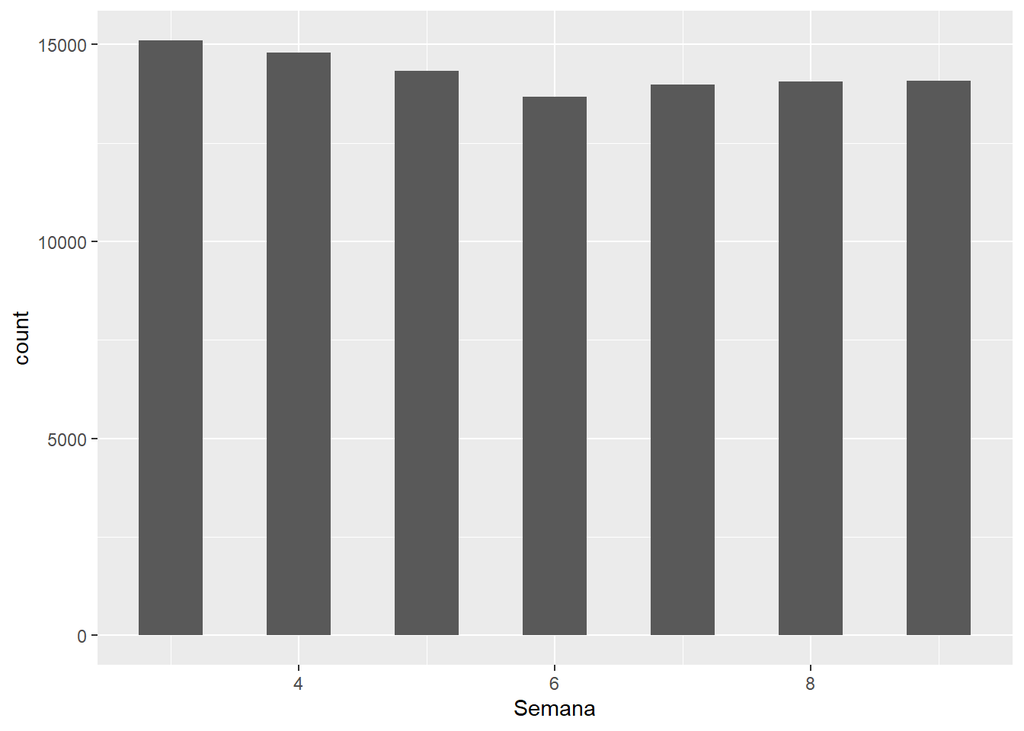

```r
ggplot(data = df_sample) +
  geom_histogram(mapping = aes(x = Semana), binwidth = 0.5)
```

“Agencia_ID” distribution:

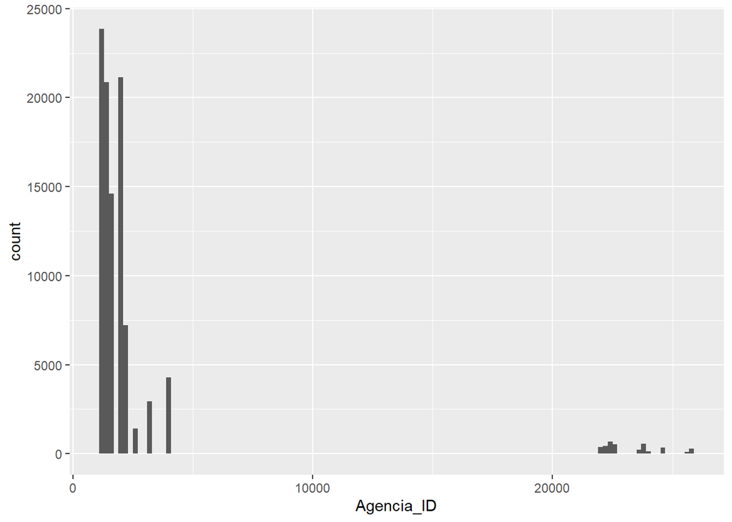

```r
ggplot(data = df_sample) +
  geom_histogram(mapping = aes(x = Agencia_ID), binwidth = 200)
```

“Canal_ID” distribution

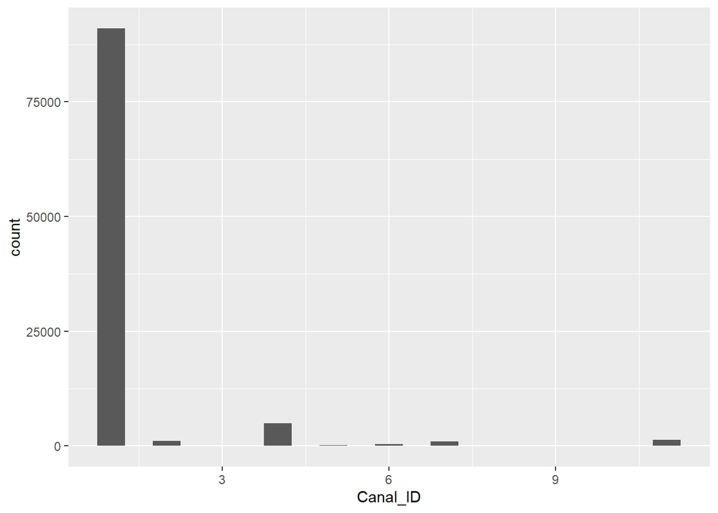

```r
ggplot(data = df_sample) +
  geom_histogram(mapping = aes(x = Canal_ID), binwidth = 0.5)
```

“Venta_uni_hoy” distribution

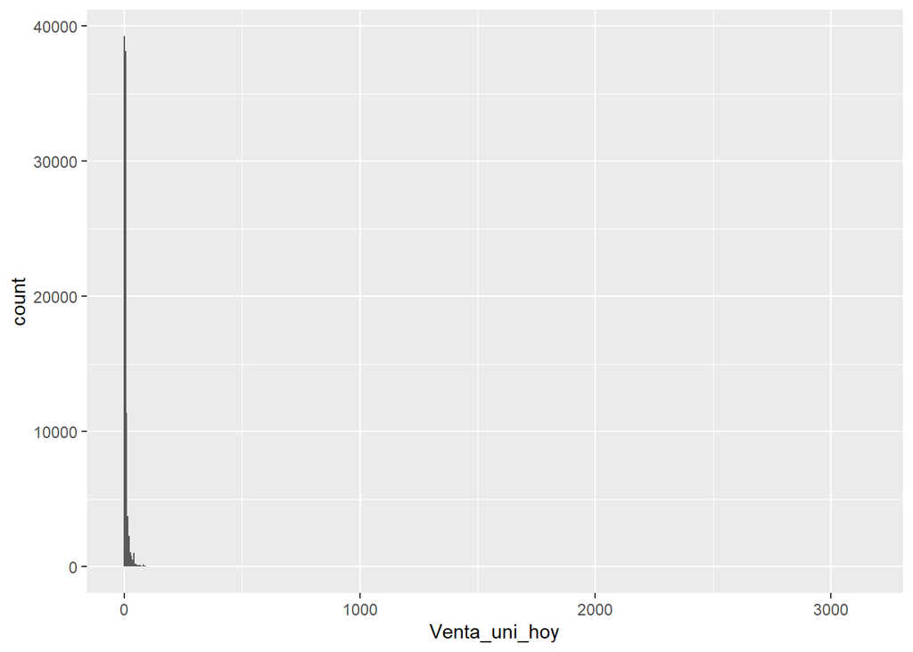

```r
ggplot(data = df_sample) +
  geom_histogram(mapping = aes(x = Venta_uni_hoy), binwidth = 5)
```

“Dev_uni_proxima” distribution

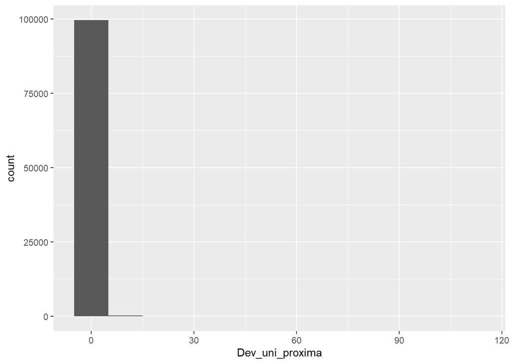

```r
ggplot(data = df_sample) +
  geom_histogram(mapping = aes(x = Dev_uni_proxima), binwidth = 10)
```

“Dev_proxima” distribution

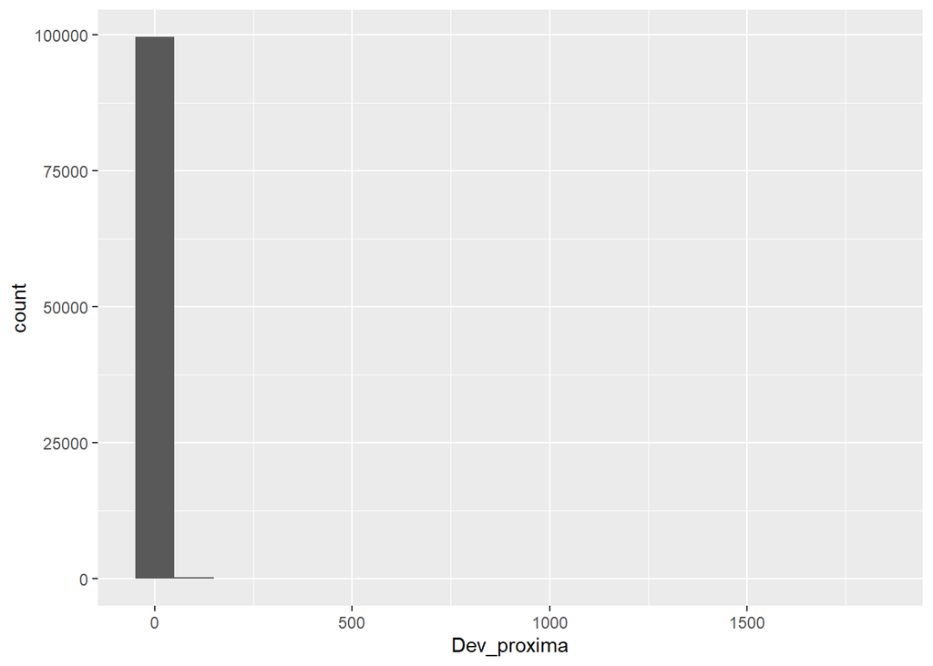

```r
ggplot(data = df_sample) +
  geom_histogram(mapping = aes(x = Dev_proxima), binwidth = 100)
```

“Demanda_uni_equil” distribution

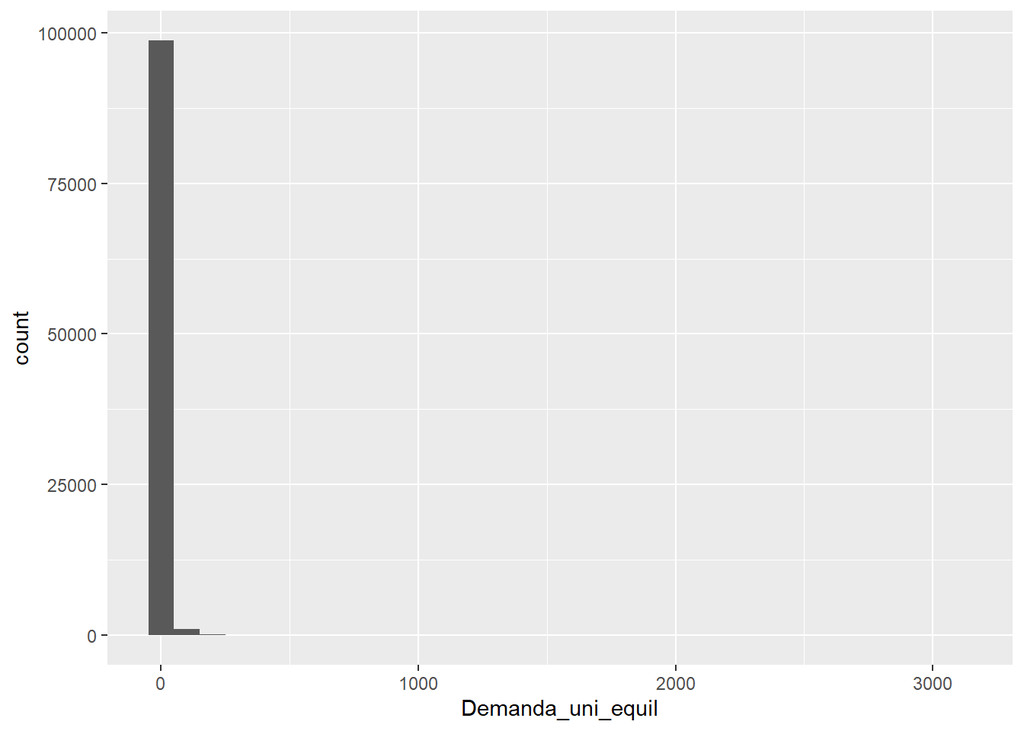

```r
ggplot(data = df_sample) +
  geom_histogram(mapping = aes(x = Demanda_uni_equil), binwidth = 100)
```

Checking outliers by “Agencia_ID”

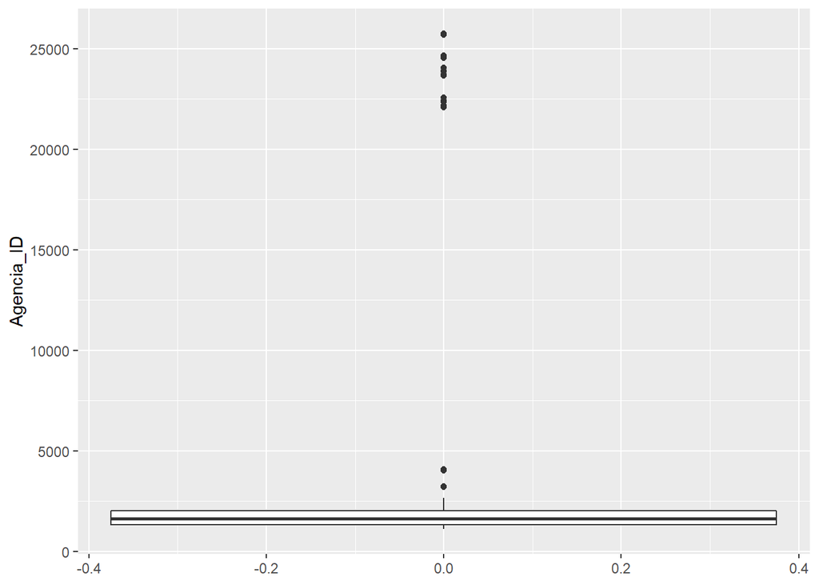

```r
ggplot(data = df_sample, mapping = aes(y = Agencia_ID)) +
  geom_boxplot()
```

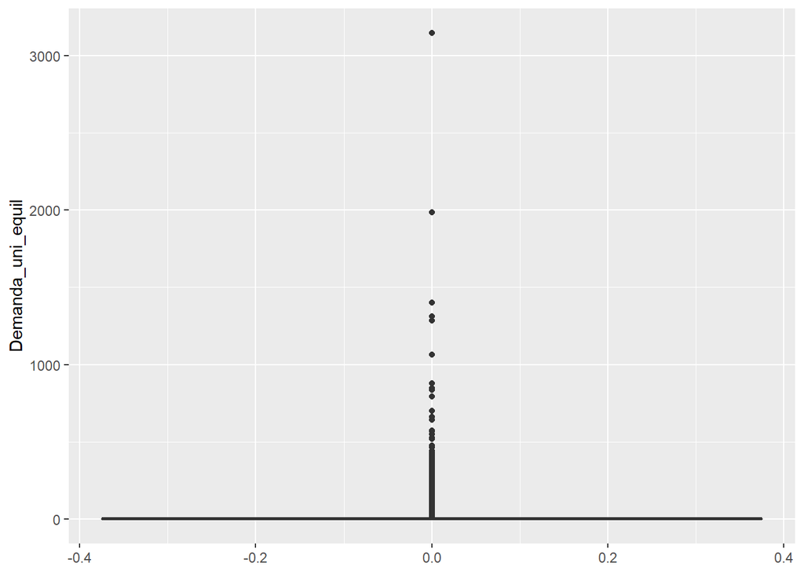

```r
ggplot(data = df_sample, mapping = aes(y = Demanda_uni_equil)) +
  geom_boxplot()
```

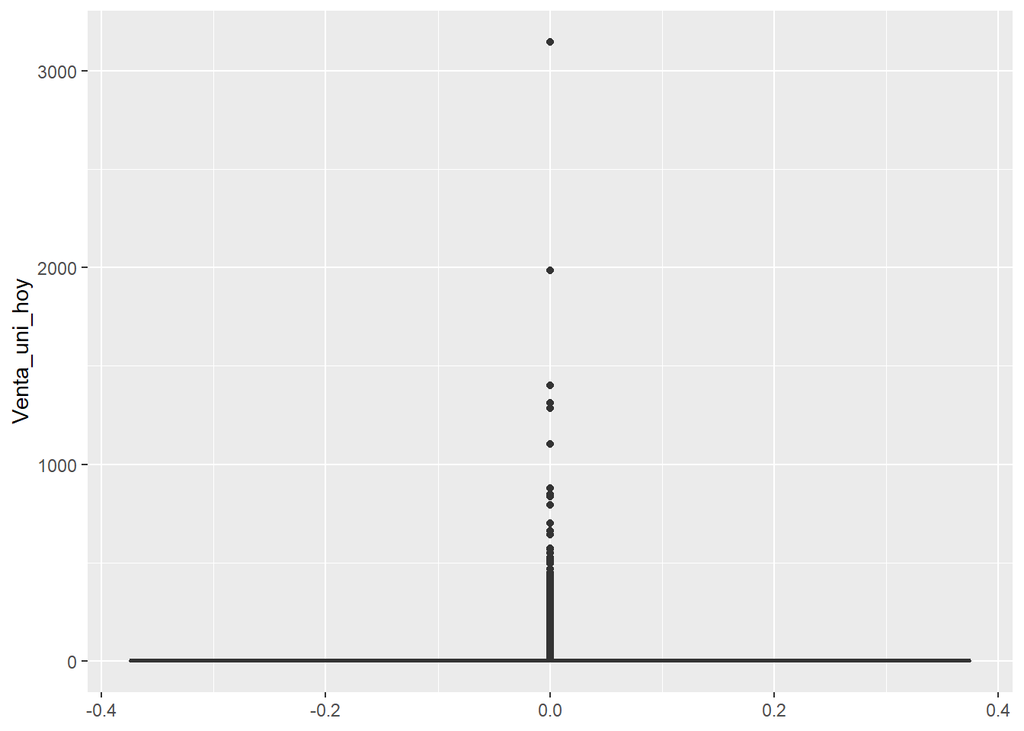

```r
ggplot(data = df_sample, mapping = aes(y = Venta_uni_hoy)) +
  geom_boxplot()
```

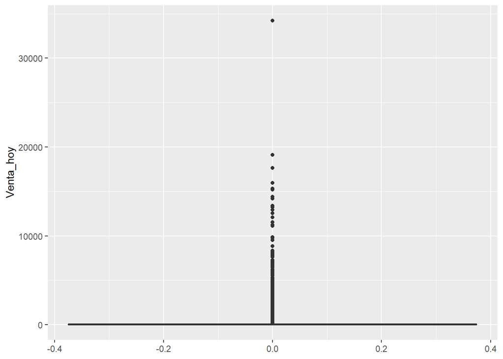

```r
ggplot(data = df_sample, mapping = aes(y = Venta_hoy)) +
  geom_boxplot()
```

It seems like observation 3885 is an outlier so we are going to remove this line

```r
df_sample <- df_sample[-c(3885), ]
```

Checking correlation between variables

```r
col_num <- sapply(df_sample, is.numeric)
data_cor <- cor(df_sample[,col_num])
melted_cormat <- melt(data_cor)
head(melted_cormat)
```

```
##          Var1   Var2        value
## 1      Semana Semana  1.000000000
## 2  Agencia_ID Semana -0.005051149
## 3    Canal_ID Semana  0.014245550
## 4    Ruta_SAK Semana  0.002776577
## 5  Cliente_ID Semana -0.002909042
## 6 Producto_ID Semana  0.017419464
```

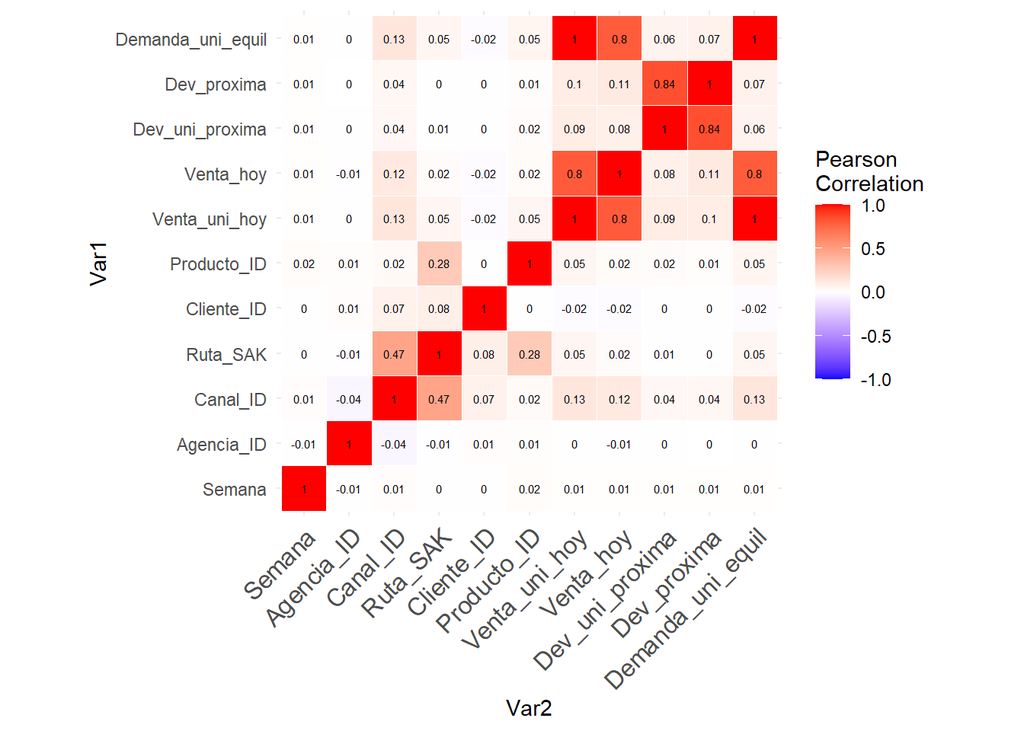

```r
ggplot(data = melted_cormat, aes(Var2, Var1, fill = value))+
  geom_tile(color = "white")+
  scale_fill_gradient2(low = "blue", high = "red", mid = "white",
                       midpoint = 0, limit = c(-1,1), space = "Lab",
                       name="Pearson\nCorrelation") +
  theme_minimal()+
  theme(axis.text.x = element_text(angle = 45, vjust = 1,
                                   size = 12, hjust = 1))+
  coord_fixed()+
  geom_text(aes(Var2, Var1, label = round(value,2)), color = "black", size = 2)
```

Correlation between “Agencia_ID” and “Demanda_uni_equil”

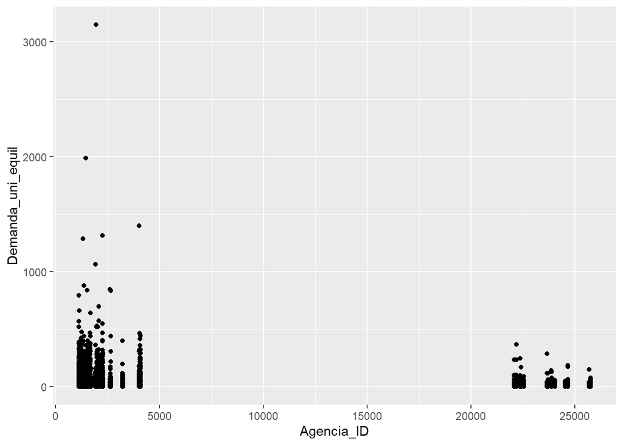

```r
ggplot(data = df_sample) +
  geom_point(mapping = aes(x = Agencia_ID, y = Demanda_uni_equil))
```

Correlation between “Venta_uni_hoy” and “Demanda_uni_equil”

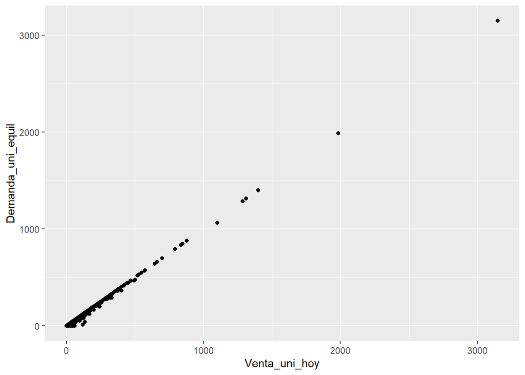

```r
ggplot(data = df_sample) +
  geom_point(mapping = aes(x = Venta_uni_hoy, y = Demanda_uni_equil))
```

Correlation between “Venta_hoy” and “Demanda_uni_equil”

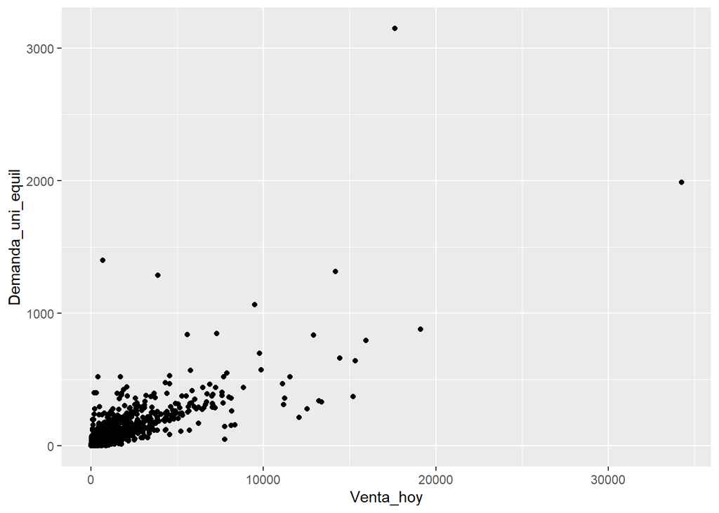

```r
ggplot(data = df_sample) +
  geom_point(mapping = aes(x = Venta_hoy, y = Demanda_uni_equil))
```

### Using dplyr to group/join data and get some insights

Top 10 sum of “Demanda_uni_equil” by State

```r
df_sample %>%
  inner_join(df_town, by = 'Agencia_ID') %>%
  select(State, Demanda_uni_equil) %>%
  group_by(State) %>%
  summarize(ave_Demanda = sum(Demanda_uni_equil)) %>%
  arrange(desc(ave_Demanda))
```

```
## # A tibble: 33 x 2
##    State            ave_Demanda
##    <chr>                  <int>
##  1 ESTADO DE MÉXICO       96583
##  2 MÉXICO, D.F.           86237
##  3 JALISCO                67292
##  4 NUEVO LEÓN             43646
##  5 GUANAJUATO             39883
##  6 PUEBLA                 36646
##  7 VERACRUZ               32227
##  8 MICHOACÁN              28298
##  9 TAMAULIPAS             21374
## 10 CHIHUAHUA              21031
## # ... with 23 more rows
```

Top 10 sum of “Demanda_uni_equil” by Town

```r
df_sample %>%
  inner_join(df_town, by = 'Agencia_ID') %>%
  select(Town, Demanda_uni_equil) %>%
  group_by(Town) %>%
  summarize(ave_Demanda = sum(Demanda_uni_equil)) %>%
  arrange(desc(ave_Demanda))
```

```
## # A tibble: 256 x 2
##    Town                      ave_Demanda
##    <chr>                           <int>
##  1 2013 AG. MEGA NAUCALPAN         14080
##  2 2011 AG. SAN ANTONIO            12304
##  3 2029 AG.IZTAPALAPA 2            11352
##  4 2251 AGUASCALIENTES NORTE        7969
##  5 2088 AG. CEYLAN                  7732
##  6 2309 NORTE                       7651
##  7 2017 AG. SANTA CLARA             6858
##  8 2019 AG. XALOSTOC                6724
##  9 2396 RUIZ CORTINEZ               6443
## 10 2293 GRANJAS MARINELA            6279
## # ... with 246 more rows
```

Top 10 sum of “Demanda_uni_equil” by NombreCliente

```r
df_sample %>%
  inner_join(df_cliente, by = 'Cliente_ID') %>%
  select(NombreCliente, Demanda_uni_equil) %>%
  group_by(NombreCliente) %>%
  summarize(ave_Demanda = sum(Demanda_uni_equil)) %>%
  arrange(desc(ave_Demanda))
```

```
## # A tibble: 43,663 x 2
##    NombreCliente               ave_Demanda
##    <chr>                             <int>
##  1 NO IDENTIFICADO                  109168
##  2 PUEBLA REMISION                   23084
##  3 LUPITA                             3421
##  4 AUTOBUSES DE LA PIEDAD             3147
##  5 CEDIS CADENA COMERCIAL OXXO        1986
##  6 MARY                               1983
##  7 CHEDRAUI TABASCO II                1617
##  8 JALISCO REMISION                   1426
##  9 TOKS GARZA SADA                    1400
## 10 LA PASADITA                        1317
## # ... with 43,653 more rows
```

Top 10 sum of “Demanda_uni_equil” by NombreProducto

```r
df_sample %>%
  inner_join(df_produto, by = 'Producto_ID') %>%
  select(NombreProducto, Demanda_uni_equil) %>%
  group_by(NombreProducto) %>%
  summarize(ave_Demanda = sum(Demanda_uni_equil)) %>%
  arrange(desc(ave_Demanda))
```

```
## # A tibble: 941 x 2
##    NombreProducto                           ave_Demanda
##    <chr>                                          <int>
##  1 Nito 1p 62g Central BIM 2425                   32822
##  2 Rebanada 2p 55g BIM 1284                       28799
##  3 Nito 1p 62g BIM 1278                           24608
##  4 Gansito 1p 50g MTB MLA 43285                   20544
##  5 Bolsa Mini Rocko 40p 13g CU MLA 36610          17637
##  6 Mantecadas Vainilla 4p 125g BIM 1240           16195
##  7 Donas Azucar 4p 105g BIM 1250                  15442
##  8 Polvoroncitos Panera 40p 16 25g TR 45143       14839
##  9 Donitas Espolvoreadas 6p 105g BIM 1242         13996
## 10 Pan Blanco 640g BIM 2233                       13376
## # ... with 931 more rows
```

Searching for distinct values in town

```r
unique(df_town$State)
```

```
##  [1] "MÉXICO, D.F."          "ESTADO DE MÉXICO"      "HIDALGO"
##  [4] "Queretaro de Arteaga"  "PUEBLA"                "OAXACA"
##  [7] "MORELOS"               "GUERRERO"              "TLAXCALA"
## [10] "JALISCO"               "COLIMA"                "ZACATECAS"
## [13] "NAYARIT"               "SAN LUIS POTOSÍ"       "AGUASCALIENTES"
## [16] "MICHOACÁN"             "TAMAULIPAS"            "NUEVO LEÓN"
## [19] "COAHUILA"              "CHIHUAHUA"             "DURANGO"
## [22] "SONORA"                "BAJA CALIFORNIA NORTE" "SINALOA"
## [25] "BAJA CALIFORNIA SUR"   "VERACRUZ"              "GUANAJUATO"
## [28] "QUERETARO"             "TABASCO"               "YUCATÁN"
## [31] "CAMPECHE"              "QUINTANA ROO"          "CHIAPAS"
```

Most important variables for the model using varImp

In this plot we can see variable importance for predicting Demanda_uni_equil

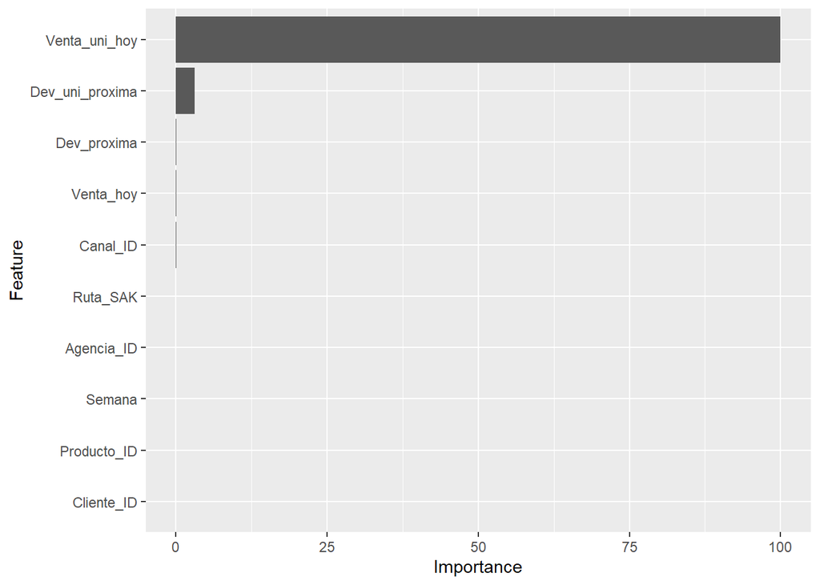

```r
modelo <- train(Demanda_uni_equil ~ ., data = df_sample, method = "lm")
vImp <- varImp(modelo)

# In this plot we can see variable importance for predicting Demanda_uni_equil
ggplot(vImp) +
  geom_bar(stat='identity')
```

```r
vImp
```

```
## lm variable importance
##
##                   Overall
## Venta_uni_hoy   1.000e+02
## Dev_uni_proxima 3.076e+00
## Dev_proxima     1.013e-01
## Venta_hoy       6.359e-02
## Canal_ID        4.896e-02
## Ruta_SAK        2.531e-02
## Agencia_ID      1.456e-02
## Semana          3.414e-03
## Producto_ID     2.331e-03
## Cliente_ID      0.000e+00
```

Separating data into train/test

```r
linha <- sample(1:nrow(df_sample), 0.7 * nrow(df_sample))
df_train <- df_sample[linha,]
df_test <- df_sample[-linha,]

dim(df_train)
```

```
## [1] 69999    11
```

```r
dim(df_test)
```

```
## [1] 30000    11
```

Normalization

```r
# Normalizing train dataset
df_n <- scale(df_train[,-11])
df_train_normalized <- as.data.frame(cbind(df_n, df_train$Demanda_uni_equil))
rm(df_n)
colnames(df_train_normalized)[11] <- "Demanda_uni_equil"

# Normalizing test dataset
df_n2 <- scale(df_test[,-11])
df_test_normalized <- as.data.frame(cbind(df_n2, df_test$Demanda_uni_equil))
rm(df_n2)
colnames(df_test_normalized)[11] <- "Demanda_uni_equil"
```

Creating the model with all variables and without pre processing

```r
modelo_v1 <- lm(Demanda_uni_equil ~ ., data = df_train)

summary(modelo_v1)
```

```
##
## Call:
## lm(formula = Demanda_uni_equil ~ ., data = df_train)
##
## Residuals:
##     Min      1Q  Median      3Q     Max
## -46.038   0.010   0.014   0.020  42.604
##
## Coefficients:
##                   Estimate Std. Error  t value Pr(>|t|)
## (Intercept)     -1.528e-02  8.157e-03   -1.873  0.06109 .
## Semana          -3.502e-04  1.102e-03   -0.318  0.75066
## Agencia_ID       3.809e-07  5.432e-07    0.701  0.48319
## Canal_ID         5.422e-03  1.754e-03    3.091  0.00199 **
## Ruta_SAK         2.257e-06  1.781e-06    1.268  0.20494
## Cliente_ID      -3.754e-10  1.208e-09   -0.311  0.75600
## Producto_ID      3.985e-08  1.246e-07    0.320  0.74898
## Venta_uni_hoy    9.981e-01  1.549e-04 6442.891  < 2e-16 ***
## Venta_hoy       -2.445e-05  1.133e-05   -2.158  0.03090 *
## Dev_uni_proxima -4.768e-01  2.648e-03 -180.093  < 2e-16 ***
## Dev_proxima     -2.219e-03  2.447e-04   -9.067  < 2e-16 ***
## ---
## Signif. codes:  0 '***' 0.001 '**' 0.01 '*' 0.05 '.' 0.1 ' ' 1
##
## Residual standard error: 0.5859 on 69988 degrees of freedom
## Multiple R-squared:  0.9994, Adjusted R-squared:  0.9994
## F-statistic: 1.246e+07 on 10 and 69988 DF,  p-value: < 2.2e-16
```

```r
previsao1 <- predict(modelo_v1, df_test)

MSE1 = MSE(y_pred=previsao1, y_true=df_test$Demanda_uni_equil)
MAE1 = MAE(y_pred=previsao1, y_true=df_test$Demanda_uni_equil)
RMSE1 = RMSE(y_pred=previsao1, y_true=df_test$Demanda_uni_equil)

#RMSLE
predicted_value = abs(previsao1)
actual_value = abs(df_test$Demanda_uni_equil)

SLE = (log(predicted_value + 1) - log(actual_value+ 1))^2

RMSLE = sqrt(mean(SLE))

Score1 = 1/(1+exp(RMSLE))
```

Creating a new dataframe with the results

```r
result <- data.frame("modelo_v1", "all variables + no preprocessing", summary(modelo_v1)$r.squared, MAE1, MSE1, RMSE1, Score1)
names(result) <-c("Model", "Variables", "R-squared", "MAE", "MSE", "RMSE", "RMSLE")
```

Creating the model2 with all variables + normalized data

```r
modelo_v2 <- lm(Demanda_uni_equil ~ ., data = df_train_normalized)

summary(modelo_v2)
```

```
##
## Call:
## lm(formula = Demanda_uni_equil ~ ., data = df_train_normalized)
##
## Residuals:
##     Min      1Q  Median      3Q     Max
## -46.038   0.010   0.014   0.020  42.604
##
## Coefficients:
##                   Estimate Std. Error  t value Pr(>|t|)
## (Intercept)      7.2706896  0.0022146 3283.119  < 2e-16 ***
## Semana          -0.0007039  0.0022153   -0.318  0.75066
## Agencia_ID       0.0015543  0.0022167    0.701  0.48319
## Canal_ID         0.0079191  0.0025616    3.091  0.00199 **
## Ruta_SAK         0.0033530  0.0026451    1.268  0.20494
## Cliente_ID      -0.0006917  0.0022261   -0.311  0.75600
## Producto_ID      0.0007449  0.0023281    0.320  0.74898
## Venta_uni_hoy   24.7611511  0.0038432 6442.891  < 2e-16 ***
## Venta_hoy       -0.0082915  0.0038414   -2.158  0.03090 *
## Dev_uni_proxima -0.7170343  0.0039815 -180.093  < 2e-16 ***
## Dev_proxima     -0.0361467  0.0039868   -9.067  < 2e-16 ***
## ---
## Signif. codes:  0 '***' 0.001 '**' 0.01 '*' 0.05 '.' 0.1 ' ' 1
##
## Residual standard error: 0.5859 on 69988 degrees of freedom
## Multiple R-squared:  0.9994, Adjusted R-squared:  0.9994
## F-statistic: 1.246e+07 on 10 and 69988 DF,  p-value: < 2.2e-16
```

```r
previsao2 <- predict(modelo_v2, df_test_normalized)

MSE2 = MSE(y_pred=previsao2, y_true=df_test_normalized$Demanda_uni_equil)
MAE2 = MAE(y_pred=previsao2, y_true=df_test_normalized$Demanda_uni_equil)
RMSE2 = RMSE(y_pred=previsao2, y_true=df_test_normalized$Demanda_uni_equil)

#RMSLE
predicted_value = abs(previsao2)
actual_value = abs(df_test_normalized$Demanda_uni_equil)

SLE = (log(predicted_value + 1) - log(actual_value+ 1))^2

RMSLE = sqrt(mean(SLE))

Score2 = 1/(1+exp(RMSLE))

# Creating a new dataframe with the results
result2 <- data.frame("modelo_v2", "all variables + normalized data", summary(modelo_v2)$r.squared, MAE2, MSE2, RMSE2, Score2)
names(result2) <-c("Model", "Variables", "R-squared", "MAE", "MSE", "RMSE", "RMSLE")
newresult <- rbind(result, result2)
```

Creating the model3 with top 3 variables and pre processing

```r
modelo_v3 <- lm(Demanda_uni_equil ~ Venta_uni_hoy +
                  Dev_uni_proxima +
                  Dev_proxima, data = df_train_normalized)

previsao3 <- predict(modelo_v3, df_test_normalized)

MSE3 = MSE(y_pred=previsao3, y_true=df_test_normalized$Demanda_uni_equil)
MAE3 = MAE(y_pred=previsao3, y_true=df_test_normalized$Demanda_uni_equil)
RMSE3 = RMSE(y_pred=previsao3, y_true=df_test_normalized$Demanda_uni_equil)

#RMSLE
predicted_value3 = abs(previsao3)
actual_value3 = abs(df_test$Demanda_uni_equil)

SLE3 = (log(predicted_value3 + 1) - log(actual_value3+ 1))^2
RMSLE3 = sqrt(mean(SLE3))
Score3 = 1/(1+exp(RMSLE3))

result3 <- data.frame("modelo_v3", "top 3 variables + normalized data", summary(modelo_v3)$r.squared, MAE3, MSE3, RMSE3, Score3)
names(result3) <-c("Model", "Variables", "R-squared", "MAE", "MSE", "RMSE", "RMSLE")
newresult <- rbind(result, result2, result3)
```

Creating the model4 with top 1 variables and pre processing

```r
modelo_v4 <- lm(Demanda_uni_equil ~ Venta_uni_hoy, data = df_train_normalized)

previsao4 <- predict(modelo_v4, df_test_normalized)

MSE4 = MSE(y_pred=previsao4, y_true=df_test_normalized$Demanda_uni_equil)
MAE4 = MAE(y_pred=previsao4, y_true=df_test_normalized$Demanda_uni_equil)
RMSE4 = RMSE(y_pred=previsao4, y_true=df_test_normalized$Demanda_uni_equil)

#RMSLE
predicted_value4 = abs(previsao4)
actual_value4 = abs(df_test$Demanda_uni_equil)

SLE4 = (log(predicted_value4 + 1) - log(actual_value4+ 1))^2
RMSLE4 = sqrt(mean(SLE4))
Score4 = 1/(1+exp(RMSLE4))

result4 <- data.frame("modelo_v4", "top 1 variable + normalized data", summary(modelo_v4)$r.squared, MAE4, MSE4, RMSE4, Score4)
names(result4) <- c("Model", "Variables", "R-squared", "MAE", "MSE", "RMSE", "RMSLE")
newresult <- rbind(result, result2, result3, result4)
```

```r
head(newresult)
```

```
##       Model                         Variables R-squared        MAE        MSE
## 1 modelo_v1  all variables + no preprocessing 0.9994384 0.06631699  0.3654095
## 2 modelo_v2   all variables + normalized data 0.9994384 1.61096514 22.7192415
## 3 modelo_v3 top 3 variables + normalized data 0.9994382 1.60969414 22.7115024
## 4 modelo_v4  top 1 variable + normalized data 0.9985293 1.64181049 24.2561680
##        RMSE     RMSLE
## 1 0.6044911 0.4736259
## 2 4.7664706 0.4175526
## 3 4.7656587 0.4175754
## 4 4.9250551 0.4172707
```

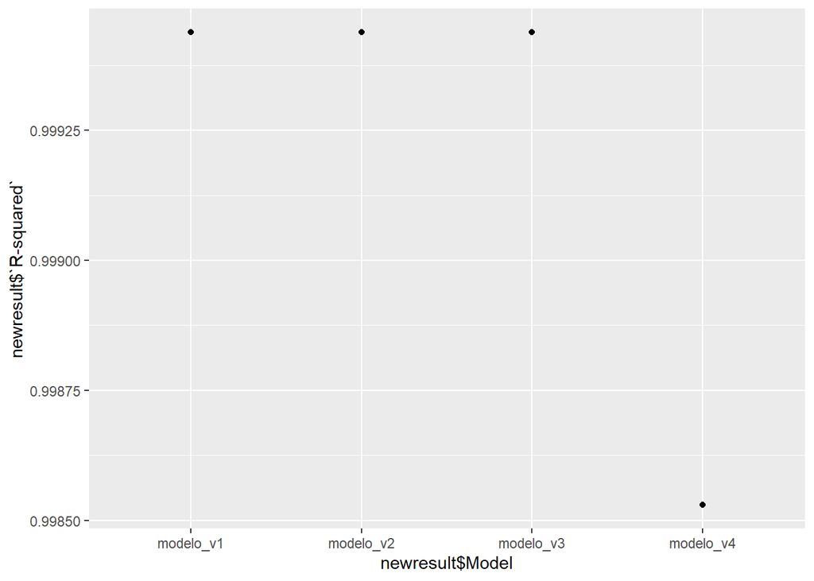

```r
#R-Squared
ggplot(data = newresult) +
  geom_point(mapping = aes(x = newresult$`Model`, y = newresult$`R-squared`))
```

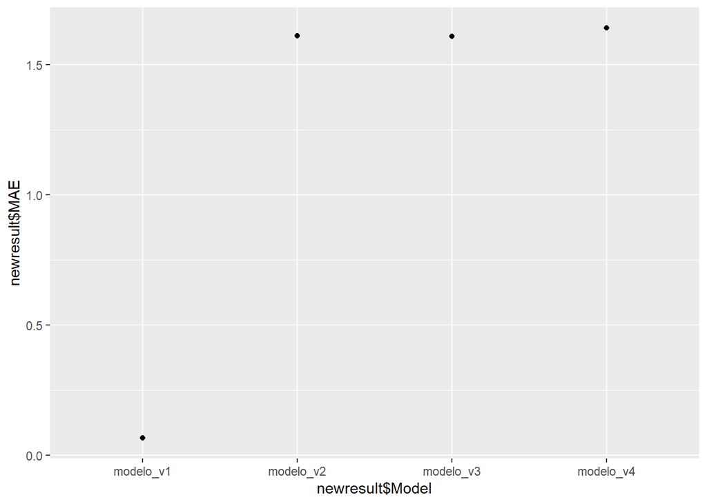

```r
#MAE
ggplot(data = newresult) +
  geom_point(mapping = aes(x = newresult$`Model`, y = newresult$`MAE`))
```

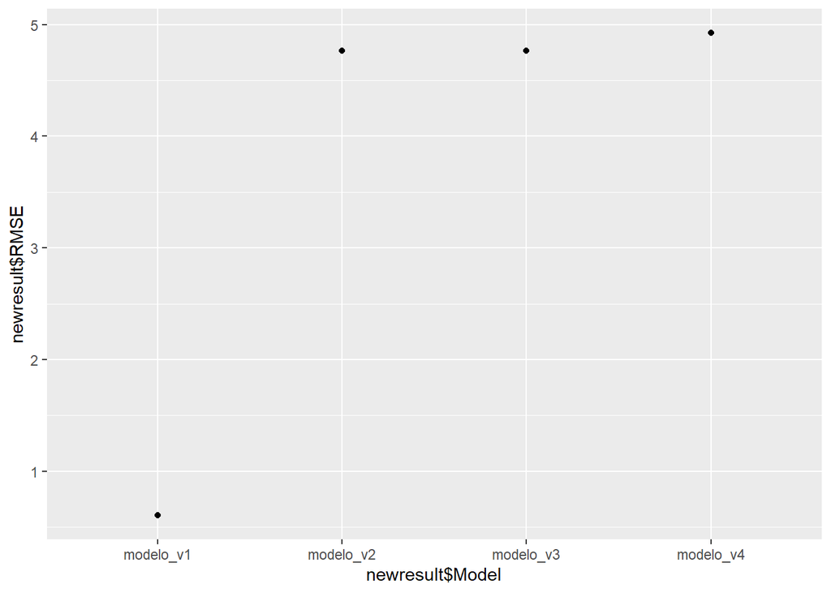

```r
#RMSE
ggplot(data = newresult) +
  geom_point(mapping = aes(x = newresult$`Model`, y = newresult$`RMSE`))
```

## Conclusions

Since our original dataset was too big (74.180.464 observations), we decided to get a 100.000 observations sample to do our analysis;

Our target variable (the one we are trying to predict) is the ‘Demanda_uni_equil’;

In the correlation plot, we can see that variable ‘Venta_uni_hoy’ have a strong positive correlation to our target. Variable ‘Venta_hoy’ also have a strong positive correlation with out target;

Variables ‘Dev_proxima’ and ‘Dev_uni_proxima’ are strongly correlated, as is variables ‘Venta_hoy’ and ‘Venta_uni_hoy’